# Reproducible Research: Peer Assessment 1

Agustín Da Fieno Delucchi

November, 2016

## Introduction

This is the first peer assessment of the Reproducible Research module. The goal of this assignment is to produce documented data analysis that includes descriptive text, code and graphics that are reproducible by anybody reviewing it.

This assignment makes use of data from a personal activity monitoring device. This device collects data at 5 minute intervals through out the day. The data consists of two months of data from an anonymous individual collected during the months of October and November, 2012 and include the number of steps taken in 5 minute intervals each day.

## Loading and preprocessing the data

Show any code that is needed to:

1. Load the data (`i.e. read.csv()`)

```r
## Create a "data" folder to host the project data to be downloaded
if (!file.exists("./data")){
  dir.create("./data")
}

## Set working directory to the new folder created
setwd("./data")

## Download and unzip the data from its original online location
file.Url <- "https://d396qusza40orc.cloudfront.net/repdata%2Fdata%2Factivity.zip"
download.file(file.Url, destfile = "actmondata.zip")
unzip("actmondata.zip")

## Read the data
cols <- c("integer", "character", "integer")
activities <- read.csv("activity.csv", head=TRUE, colClasses = cols, na.strings = "NA")
```

2. Process/transform the data (if necessary) into a format suitable for your analysis.

```r
## Convert raw text date information into an actual data format
activities$date <- as.Date(activities$date)

## Create an alternative data set without missing values
activities.no.nas <- subset(activities, !is.na(activities$steps))
```

## What is the mean total number of steps taken per day?

For this part of the assignment, you can ignore the missing values in the dataset.

1. Calculate the total number of steps taken per day.

```r
total.daily.steps <- tapply(activities.no.nas$steps, activities.no.nas$date, sum, na.rm = TRUE)
```

2. Make a histogram of the total number of steps taken each day.

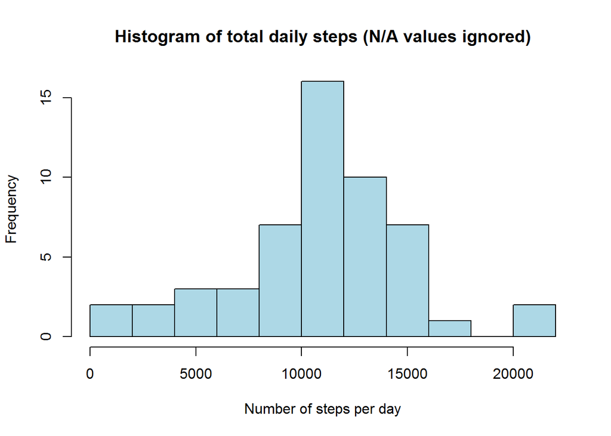

```r
hist(x=total.daily.steps,
     col = "lightblue",
     breaks=10,
     xlab = "Number of steps per day",
     ylab = "Frequency",
     main = "Histogram of total daily steps (N/A values ignored)"
     )
```

3. Calculate and report the mean and median of the total number of steps taken per day.

```r
print(paste("Mean of total number of daily steps: ", round(mean(total.daily.steps),2)))
```

```
## [1] "Mean of total number of daily steps:  10766.19"
```

```r
print(paste("Median of total number of daily steps: ", median(total.daily.steps)))
```

```
## [1] "Median of total number of daily steps:  10765"
```

## What is the average daily activity pattern?

1. Make a time series plot (`i.e. type = "l"`) of the 5-minute interval (`x-axis`) and the average number of steps taken, averaged across all days (`y-axis`).

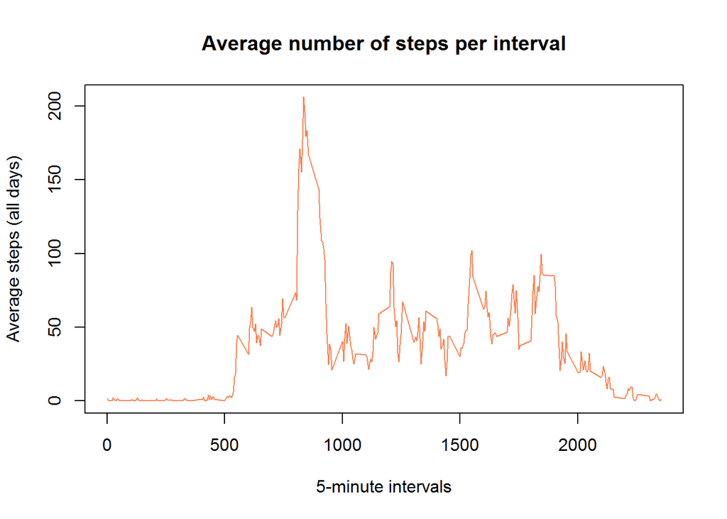

```r
## Calculate the mean for steps at each time internal
interval.average.steps.array <- tapply(activities$steps, activities$interval, mean, na.rm=TRUE)

## Convert the array to a data frame
interval.average.steps <- data.frame(interval=as.integer(names(interval.average.steps.array)), avg = interval.average.steps.array)

## Plotting the time series
with(interval.average.steps,
     plot(interval,
          avg,
          col = "coral",
          type = "l",
          xlab = "5-minute intervals",
          ylab = "Average steps (all days)",
          main = "Average number of steps per interval"))
```

2. Which 5-minute interval, on average across all the days in the dataset, contains the maximum number of steps?

```r
## Find the 5-minute interval with the maximun number of steps
maximus = interval.average.steps[interval.average.steps$avg == max(interval.average.steps$avg), ]
print(paste("The 5-minute interval containing the maximum number of steps is", maximus[1]))
```

```
## [1] "The 5-minute interval containing the maximum number of steps is 835"
```

## Imputing missing values

Note that there are a number of days/intervals where there are missing values (`coded as NA`). The presence of missing days may introduce bias into some calculations or summaries of the data.

1. Calculate and report the total number of missing values in the dataset (`i.e. the total number of rows with NAs`).

```r
print(paste("The total number of missing values in the dataset is", sum(is.na(activities$steps))))
```

```
## [1] "The total number of missing values in the dataset is 2304"
```

2. Devise a strategy for filling in all of the missing values in the dataset. The strategy does not need to be sophisticated. For example, you could use the mean/median for that day, or the mean for that 5-minute interval, etc.

My strategy is to replace the missing step values with the median for the corresponding 5-minute interval accross all days.

```r
## Obtain the median per time interval, accross all days
interval.median.steps.array <- tapply(activities.no.nas$steps, activities.no.nas$interval, median, na.rm=TRUE)
```

3. Create a new dataset that is equal to the original dataset but with the missing data filled in.

```r
## Create a data replicat to fill empty values
activities.nas.filled <- activities
## Replace empty values with the median for the corresponding time interval
activities.nas.filled[is.na(activities.nas.filled$steps),1]<-as.numeric(interval.median.steps.array[as.character(activities.nas.filled[is.na(activities.nas.filled$steps),3])])
```

4. Make a histogram of the total number of steps taken each day, and calculate and report the mean and median total number of steps taken per day. Do these values differ from the estimates from the first part of the assignment? What is the impact of imputing missing data on the estimates of the total daily number of steps?

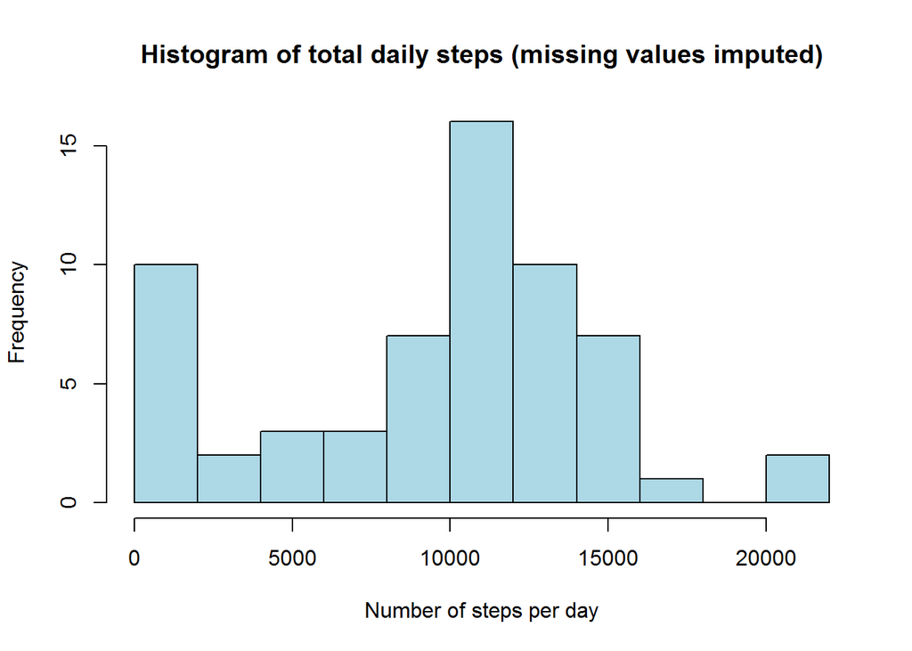

```r
## Gathering daily step frequency
new.total.daily.steps <- tapply(activities.nas.filled$steps, activities.nas.filled$date, sum, na.rm = TRUE)

## Plotting
hist(x=new.total.daily.steps,
     col="lightblue",
     breaks=10,
     xlab="Number of steps per day",
     ylab="Frequency",
     main="Histogram of total daily steps (missing values imputed)")
```

```r
print(paste("Mean of total number of daily steps: ", round(mean(new.total.daily.steps),2)))
```

```
## [1] "Mean of total number of daily steps:  9503.87"
```

```r
print(paste("Median of total number of daily steps: ", median(new.total.daily.steps)))
```

```
## [1] "Median of total number of daily steps:  10395"
```

The values obtained when imputing data are significantly different to those when not. As we can see in the histogram, there are many more values of 0 for the earlier day intervals, since we assummed the median of steps for that 5-minute interval across days. That made both the mean and median to be lower in the second dataset (filled values) than that of the firts (no NAs).

Imputing data, when done with an appropriate method (least possible bias), will enrich your datasets, but it would certainly bias your data.

## Are there differences in activity patterns between weekdays and weekends?

For this part the weekdays() function may be of some help here. Use the dataset with the filled-in missing values for this part.

1. Create a new factor variable in the dataset with two levels – “weekday” and “weekend” indicating whether a given date is a weekday or weekend day.

```r
## Creating new factor by temporarily adding the day of week names as values
activities.nas.filled$weekperiod <- weekdays(activities.nas.filled$date)

## Replacing the day of week names with their corresponding weekperiod (first step for weekdays, second for weekends)
activities.nas.filled$weekperiod <- replace(activities.nas.filled$weekperiod, activities.nas.filled$weekperiod %in% c("Monday", "Tuesday", "Wednesday", "Thursday", "Friday"), "weekday")
activities.nas.filled$weekperiod <- replace(activities.nas.filled$weekperiod, activities.nas.filled$weekperiod %in% c("Saturday", "Sunday"), "weekend")
```

2. Make a panel plot containing a time series plot (`i.e. type = "l"`) of the 5-minute interval (`x-axis`) and the average number of steps taken, averaged across all weekday days or weekend days (`y-axis`).

```r
library(dplyr)
```

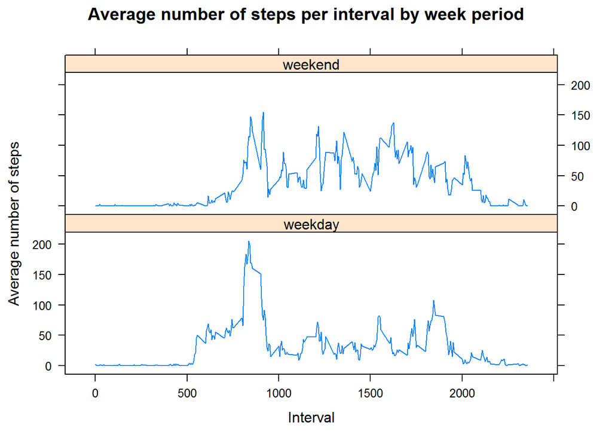

```r
## Summarizing steps per interval per weekperiod
new.interval.average.steps <- summarise(group_by(activities.nas.filled, interval, weekperiod), mean(steps))

## Renaming field containing average steps
names(new.interval.average.steps)[3] <- "avg"

## Plotting
library(lattice)
xyplot(avg~interval|weekperiod,
       data=new.interval.average.steps, type="l",  layout = c(1,2),main="Average number of steps per interval by week period", ylab="Average number of steps", xlab="Interval")
```

The data shows earlier activity happening during the weekdays, as well as less activity thougout the day during weekdays, with a couple of peeks. We can also see that, during weekends, there’s less activity in the earlier intervals, but more activity througout the day, including during the later intervals of the day.